# 2025-topic-03-group-02-code

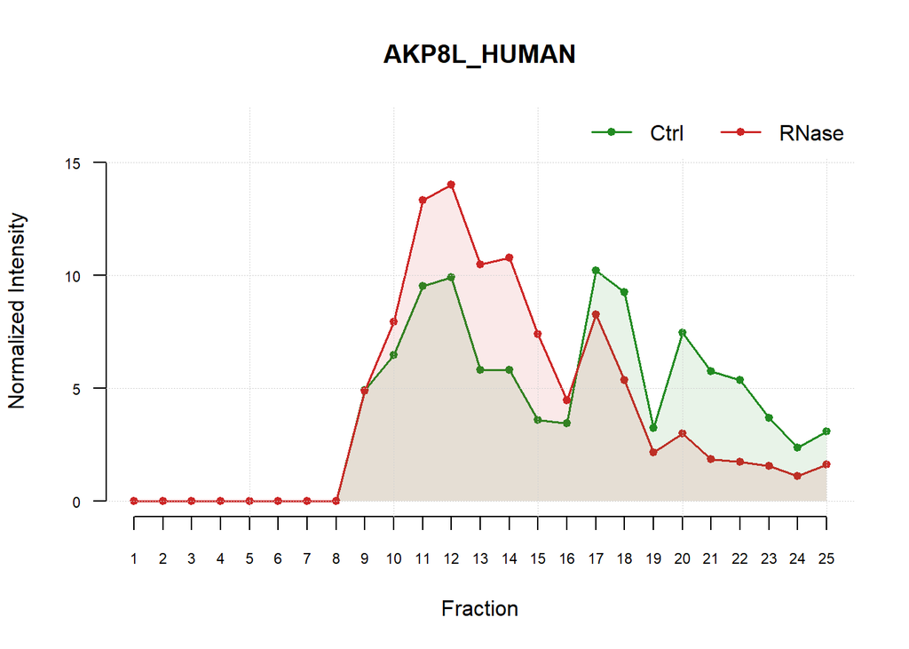

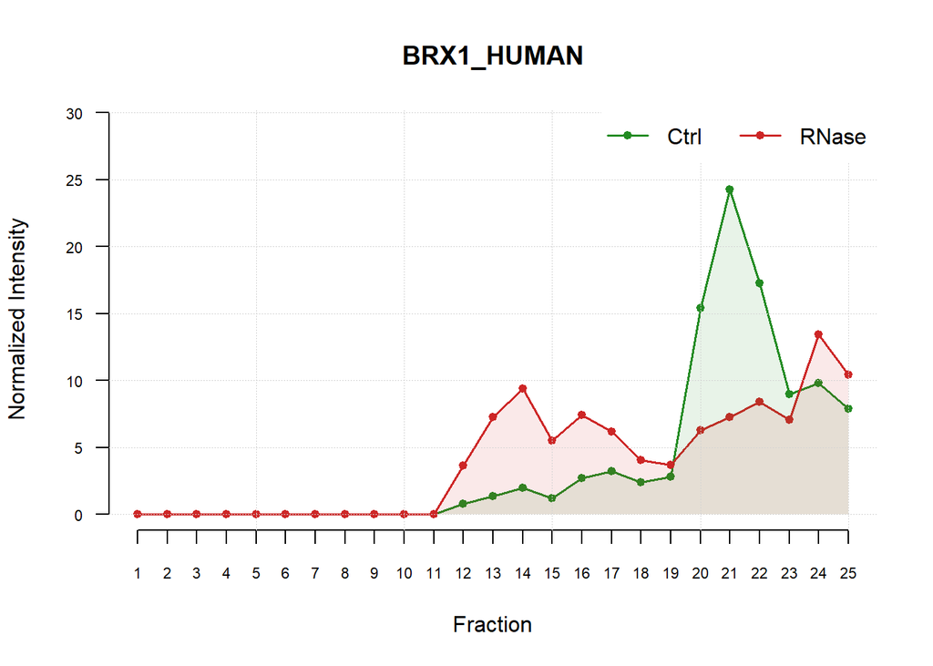

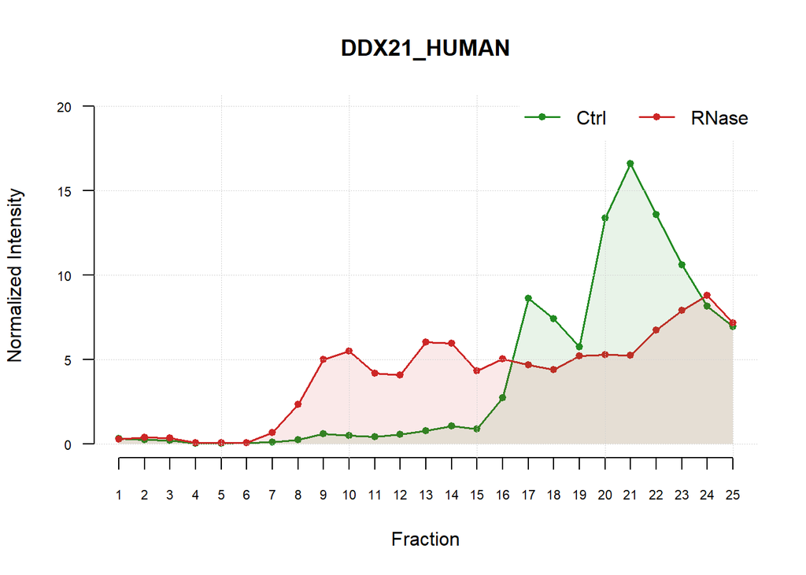

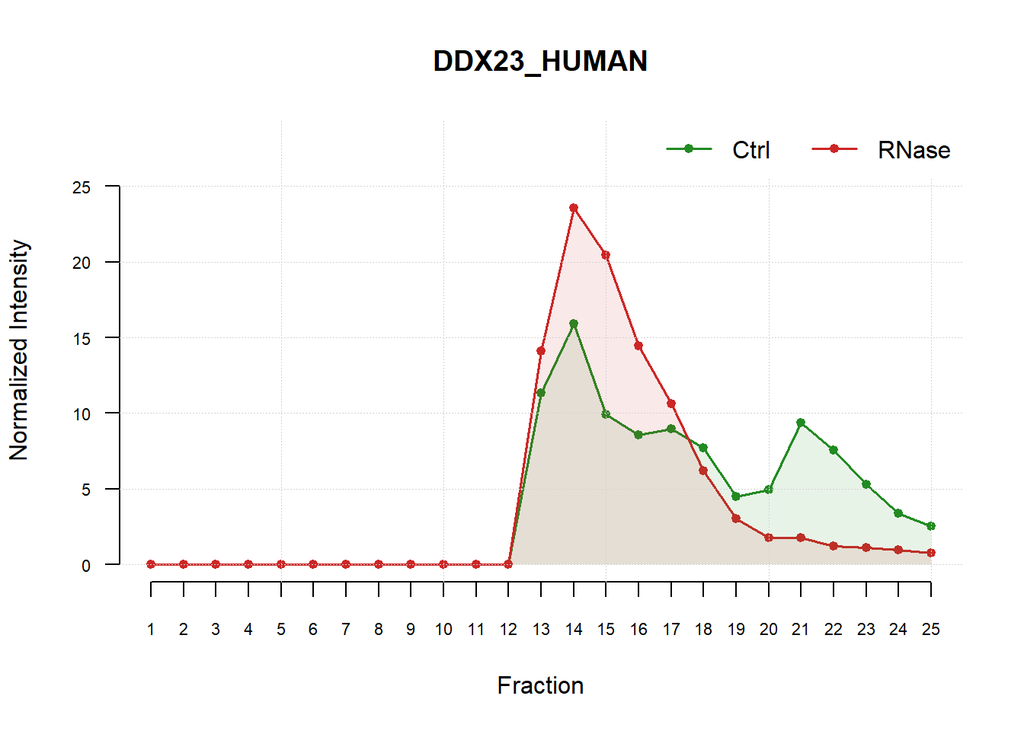

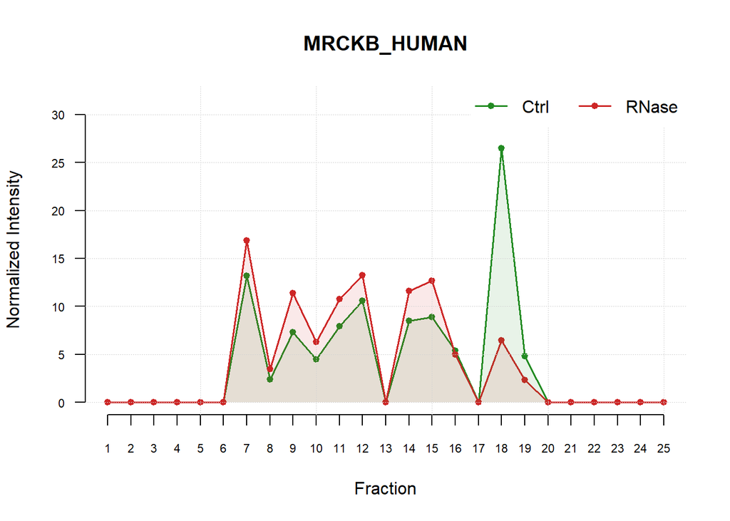

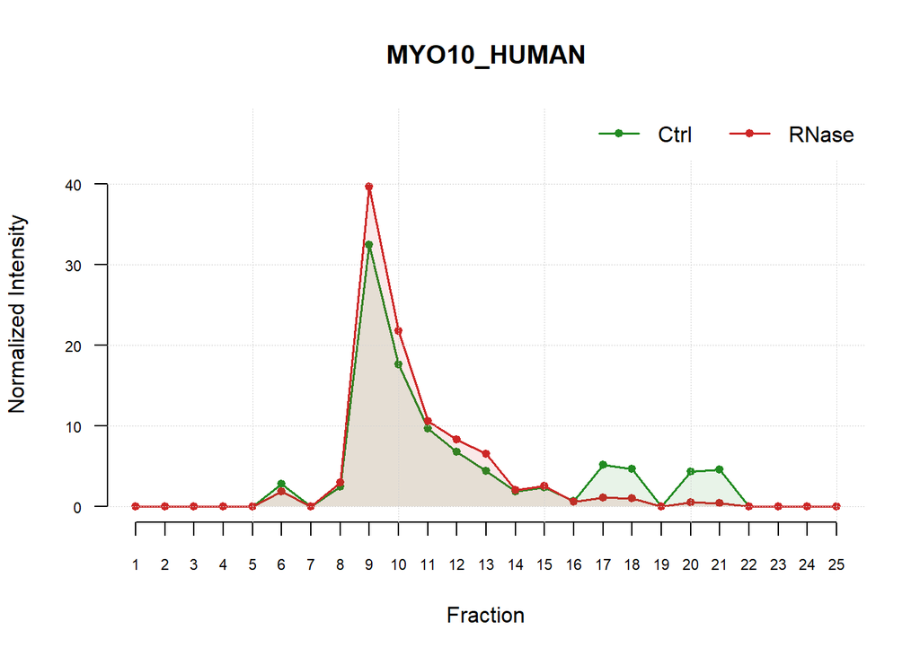

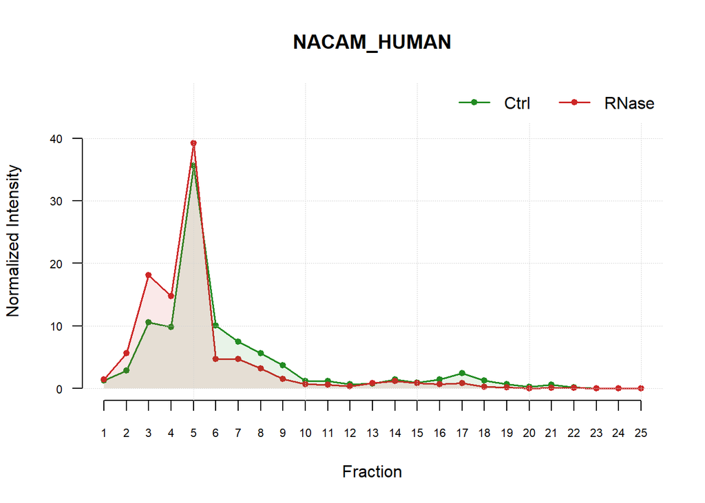

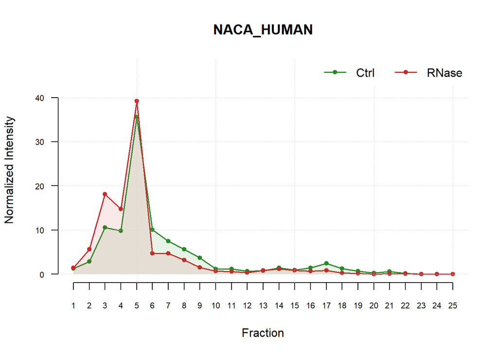

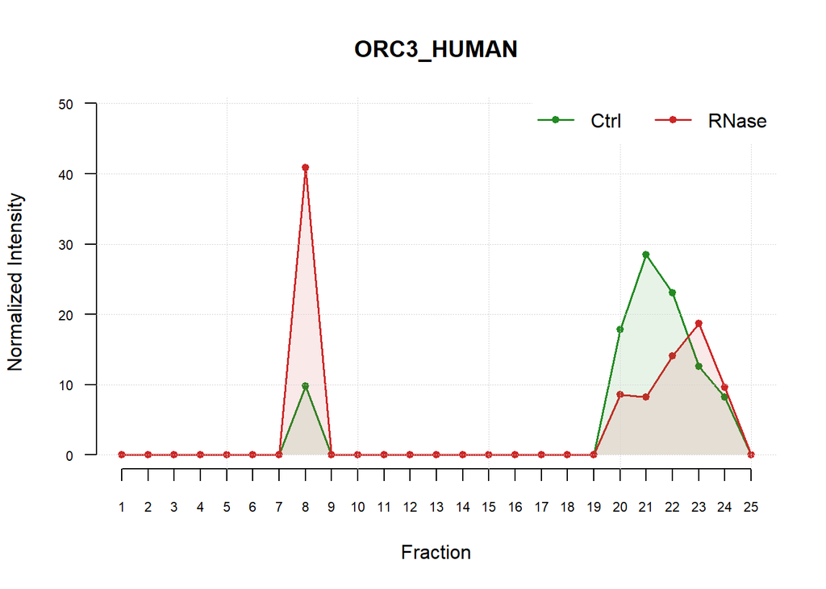

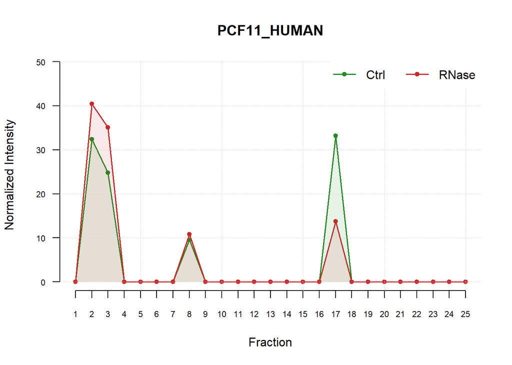

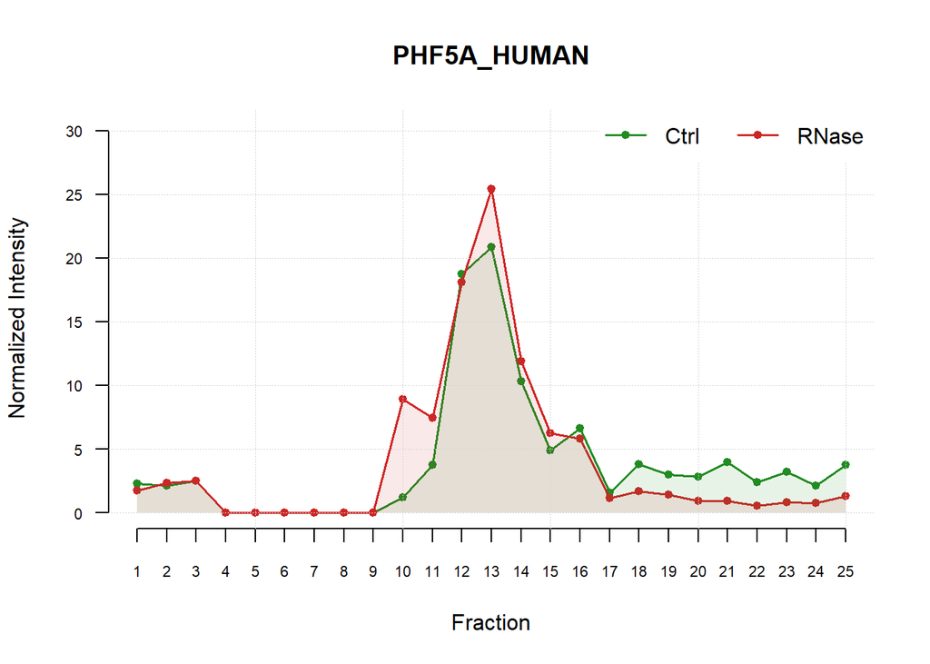

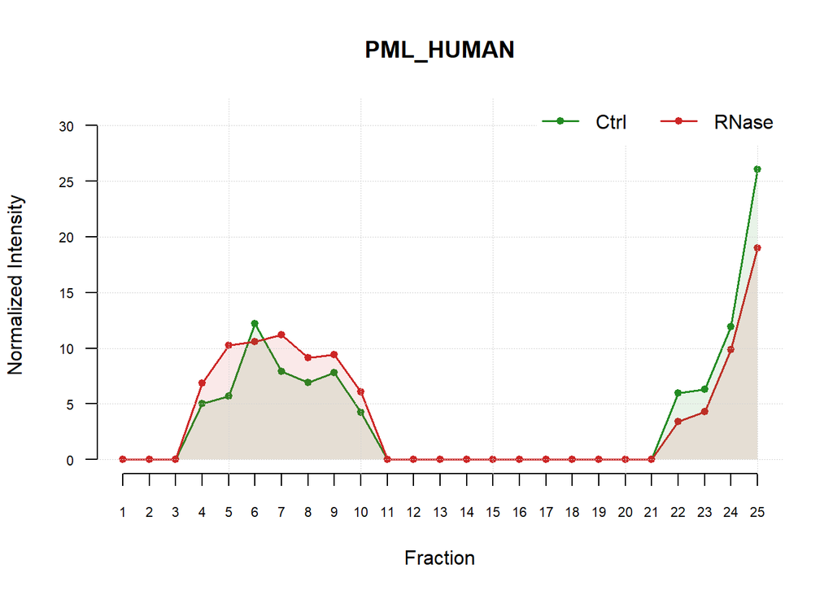

[6 more figures not shown]

```r
# Visual inspection of proteins with marginally significant p-values (above 0.045)
t_test_positives_critical_p_value <- rownames(
  Shift_Data[
    Shift_Data$significant_ttest_filtered == TRUE &
    !is.na(Shift_Data$significant_ttest_filtered) &
    Shift_Data$p_value_ttest_filtered > 0.045,
  ]
)
for (s in t_test_positives_critical_p_value){
  plot_protein(s)
}
```

```r
glue("Furthermore, of all proteins with p-values > 0.045 (n = 18), only 4 were judged inconsistent with an RBP-like shift profile, suggesting that most borderline cases still show convincing shift patterns.")
```

```
## Furthermore, of all proteins with p-values > 0.045 (n = 18), only 4 were judged inconsistent with an RBP-like shift profile, suggesting that most borderline cases still show convincing shift patterns.
```

### Plot Validation of T-test with UniProt Data - Lina

### Goal:

- This plot extends the CoM-based T-test visualization by highlighting known RBPs from UniProt.
- This view helps assess the sensitivity and limitations of the shift-based identification method relative to external RBP annotations.

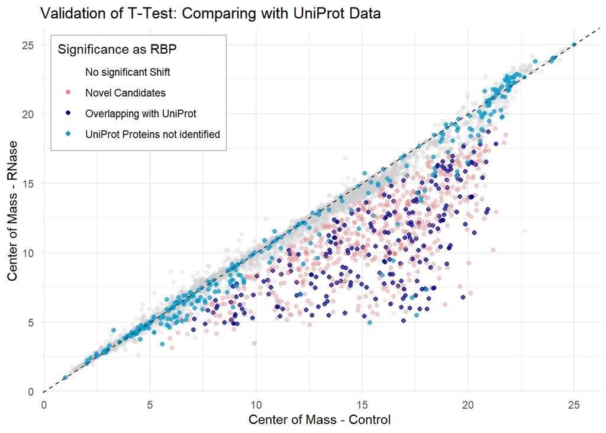

```r
# Create data subset of proteins for highlighting (was necessary for coloring sequence)
highlight_data <- subset(Shift_Data,
                         rownames(Shift_Data) %in% overlap_t_test |
                         rownames(Shift_Data) %in% not_identified |
                         rownames(Shift_Data) %in% novel_candidates)

# Classify each protein into a color group
highlight_data$color_group <- case_when(
  rownames(highlight_data) %in% overlap_t_test ~ "Overlapping with UniProt",
  rownames(highlight_data) %in% not_identified ~ "UniProt Proteins not identified",
  rownames(highlight_data) %in% novel_candidates ~ "Novel Candidates"
)

# Control transparency depending on group
highlight_data$alpha_group <- case_when(
  highlight_data$color_group == "Overlapping with UniProt" ~ "high",
  highlight_data$color_group == "UniProt Proteins not identified" ~ "high",
  highlight_data$color_group == "Novel Candidates" ~ "low"
)

# Base plot: all proteins shown in background
ggplot(Shift_Data, aes(x = `CoM_Ctrl`, y = `CoM_RNase`)) +

    # Background: all non-highlighted proteins in light gray
    geom_point(aes(color = "No significant Shift"), alpha = 0.3, show.legend = FALSE) +

    # Highlighted groups: UniProt hits, misses, and T-test positives
    geom_point(data = highlight_data,
             aes(color = color_group, alpha = alpha_group)) +
    scale_color_manual(name = "Significance as RBP",values = c(
    "No significant Shift" = "gray80",
    "Novel Candidates" = "lightcoral",
    "Overlapping with UniProt" = "darkblue",
    "UniProt Proteins not identified" = "#009ACD"
    ))+
    scale_alpha_manual(values = c("high" = 0.7, "low" = 0.3), guide = "none") +

  geom_abline(slope = 1, intercept = 0, linetype = "dashed", color = "gray20") +
  labs(title = "Validation of T-Test: Comparing with UniProt Data",
       x = "Center of Mass - Control",
       y = "Center of Mass - RNase") +
  theme_minimal()+
  theme(
    legend.position = c(0.02, 0.98),
    legend.justification = c("left", "top"),
    legend.background = element_rect(fill = "white",color = "gray70")
    )
```

## T-Test for non-synchronised HELA Cells - Lina

- This section reproduces all necessary pipeline steps with adjusted variable names.

**NOTE:** All variables related to the non-synchronized dataset are suffixed with `_NS`.

```r
# Loading Data
MS_Table_NS <- read.table("Datasets/RDeeP_HeLa_NS.csv", header = TRUE, row.names = 1, sep = ";")

# Dataframe
treatment <- factor(rep(c("Ctrl", "RNase"), each = 3, length.out = 150))
replicate <- factor(rep(c("Ctrl_Rep1", "Ctrl_Rep2", "Ctrl_Rep3", "RNase_Rep1","RNase_Rep2", "RNase_Rep3"),25))
fraction <- factor(rep(paste0("Fraction_", 1:25), each = 6))

data <- data.frame(rownames = colnames(MS_Table),treatment = treatment, replicate = replicate, fraction = fraction)

# Normalization of triplicates
average.list.NS <- list()

for (f in levels(fraction)) {

  cols.Ctrl <- which(fraction == f & treatment == "Ctrl")
  average.Ctrl <- rowMeans(MS_Table_NS[,cols.Ctrl])
  average.list.NS[[paste0("Ctrl_",f)]] <- average.Ctrl

  cols.RNase <- which(fraction == f & treatment == "RNase")
  average.RNase <- rowMeans(MS_Table_NS[,cols.RNase])
  average.list.NS[[paste0("RNase_",f)]] <- average.RNase
}

MS_Table_Averages_NS <- as.data.frame(average.list.NS)
rownames(MS_Table_Averages_NS) <- rownames(MS_Table_NS)

fractions <- paste0("Fraction_", 1:25)

ordered_names <- as.vector(rbind(
  paste0("Ctrl_", fractions),
  paste0("RNase_", fractions)
))

MS_Table_Averages_NS <- MS_Table_Averages_NS[, ordered_names]

# Normalization to 100

ctrl_cols <- grep("^Ctrl_", colnames(MS_Table_Averages_NS))
rnase_cols <- grep("^RNase_", colnames(MS_Table_Averages_NS))

ctrl_norm <- MS_Table_Averages_NS[, ctrl_cols] / rowSums(MS_Table_Averages_NS[, ctrl_cols]) * 100
rnase_norm <- MS_Table_Averages_NS[, rnase_cols] / rowSums(MS_Table_Averages_NS[, rnase_cols]) * 100

MS_Table_Norm_NS <- cbind(ctrl_norm, rnase_norm)
MS_Table_Norm_NS <- MS_Table_Norm_NS[, colnames(MS_Table_Averages_NS)]

# Function for protein plotting
plot_protein_NS <- function(x) {
  protein_of_interest <- x
  protein_row <- MS_Table_Norm_NS[rownames(MS_Table_Norm_NS) == protein_of_interest, ]
  ctrl_values <- as.numeric(protein_row[seq(1, 49, by=2)])
  rnase_values <- as.numeric(protein_row[seq(2, 50, by=2)])
  fractions <- 1:25
  max_val <- max(ctrl_values, rnase_values, na.rm = TRUE)
  ylim_range <- c(0, max_val * 1.1)

  plot(fractions, ctrl_values, type="o", pch=20, lty=1, lwd =1.5, col="forestgreen", ylim=range(c(ctrl_values, rnase_values)),
       xlab="Fraction", ylab="Normalized Intensity", main= paste(protein_of_interest, "non-synchronised"), axes = FALSE)

  lines(fractions, rnase_values, type="o",pch =20, lty=1,lwd =1.5, col="firebrick3")

  polygon(c(fractions, rev(fractions)),
          c(ctrl_values, rep(0, length(ctrl_values))),
          col=adjustcolor("forestgreen", alpha.f=0.1), border=NA)

  polygon(c(fractions, rev(fractions)),
          c(rnase_values, rep(0, length(rnase_values))),
          col=adjustcolor("firebrick3", alpha.f=0.1), border=NA)

  axis(1, at = 1:25, labels = 1:25, cex.axis = 0.7)
  axis(2, cex.axis = 0.7, las =2)
  grid(nx = NULL, ny = NULL, col = "lightgray", lty = "dotted", lwd = 0.8)

  legend("topright", legend=c("Ctrl", "RNase"), col=c("forestgreen", "firebrick3"),
         lty=1, lwd = 1.5,  pch=20, bg = "white", bty = "o", box.col = NA)
}

# Shift Characteristics based on normalized Data and CoM
x <- 1:25

CoM_Ctrl_NS <- numeric(nrow(MS_Table_Norm_NS))
CoM_RNase_NS <- numeric(nrow(MS_Table_Norm_NS))
shift_distance_NS <- numeric(nrow(MS_Table_Norm_NS))
shift_direction_NS <- numeric(nrow(MS_Table_Norm_NS))

for (p in seq_len(nrow(MS_Table_Norm_NS))) {

  row_vals <- as.numeric(MS_Table_Norm_NS [p,])
  ctrl_vals <- row_vals[seq(1, 50, by =2)]
  rnase_vals <- row_vals[seq(2, 50, by=2)]

  CoM_Ctrl_NS[p] <- sum(ctrl_vals * x) / sum(ctrl_vals)
  CoM_RNase_NS[p] <- sum(rnase_vals * x) / sum(rnase_vals)
  shift_distance_NS[p] <- CoM_Ctrl_NS[p] - CoM_RNase_NS[p]
  shift_direction_NS[p] <- sign(shift_distance_NS[p])
}

Shift_Data_NS <- data.frame(
  CoM_Ctrl= CoM_Ctrl_NS,
  CoM_RNase = CoM_RNase_NS,
  shift_distance = shift_distance_NS,
  shift_direction= shift_direction_NS,
  row.names = rownames(MS_Table_Norm_NS))

# Normalization of MS_Table_NS to 100

ctrl_cols_t1 <- grep("_Ctrl_Rep1", colnames(MS_Table_NS))
ctrl_cols_t2 <- grep("_Ctrl_Rep2", colnames(MS_Table_NS))
ctrl_cols_t3 <- grep("_Ctrl_Rep3", colnames(MS_Table_NS))
RNase_cols_t1 <- grep("_RNase_Rep1", colnames(MS_Table_NS))
RNase_cols_t2 <- grep("_RNase_Rep2", colnames(MS_Table_NS))
RNase_cols_t3 <- grep("_RNase_Rep3", colnames(MS_Table_NS))

ctrl_norm_t1 <- MS_Table_NS[, ctrl_cols_t1] / rowSums(MS_Table_NS[, ctrl_cols_t1]) * 100
ctrl_norm_t2 <- MS_Table_NS[, ctrl_cols_t2] / rowSums(MS_Table_NS[, ctrl_cols_t2]) * 100
ctrl_norm_t3 <- MS_Table_NS[, ctrl_cols_t3] / rowSums(MS_Table_NS[, ctrl_cols_t3]) * 100
RNase_norm_t1 <- MS_Table_NS[, RNase_cols_t1] / rowSums(MS_Table_NS[, RNase_cols_t1]) * 100
RNase_norm_t2 <- MS_Table_NS[, RNase_cols_t2] / rowSums(MS_Table_NS[, RNase_cols_t2]) * 100
RNase_norm_t3 <- MS_Table_NS[, RNase_cols_t3] / rowSums(MS_Table_NS[, RNase_cols_t3]) * 100

Norm_Data_for_t_NS <- cbind(ctrl_norm_t1, RNase_norm_t1, ctrl_norm_t2, RNase_norm_t2, ctrl_norm_t3, RNase_norm_t3)

fractions <- 1:25
reps <- 1:3
conditions <- c("Ctrl", "RNase")
ordered_names <- c()
for (fraction in fractions) {
  for (rep in reps) {
    for (condition in conditions) {
      name <- paste0("Fraction", fraction, "_", condition, "_Rep", rep)
      ordered_names <- c(ordered_names, name)
    }
  }
}
Norm_Data_for_t_NS <- Norm_Data_for_t_NS[, ordered_names]

# Calculation of CoM for T-Test

fractions <- 1:25
conditions <- c("Ctrl", "RNase")
replicates <- c("Rep1", "Rep2", "Rep3")

results_com_NS <- list()

for (cond in conditions) {
  for (rep in replicates) {
    pattern <- paste0("^Fraction", fractions, "_", cond, "_", rep, "$")
    cols <- grep(paste(pattern, collapse="|"), colnames(Norm_Data_for_t_NS), value = TRUE)
    subdata <- Norm_Data_for_t_NS[, cols]
    subdata <- subdata[, order(as.numeric(gsub("Fraction(\\d+)_.*", "\\1", cols)))]
    com <- apply(subdata, 1, function(x) {
      sum(x * fractions) / sum(x)
    })

    results_com_NS[[paste(cond, rep, sep = "_")]] <- com
  }
}

CoM_Data_for_t_NS <- as.data.frame(results_com_NS)

rownames(CoM_Data_for_t_NS) <- rownames(Norm_Data_for_t_NS)

# Calculating Shift-Values for T-Test

Shift_Data_for_t_NS <- data.frame(
  shift_distance_rep1 = CoM_Data_for_t_NS[, 1] - CoM_Data_for_t_NS[, 4],
  shift_distance_rep2 = CoM_Data_for_t_NS[, 2] - CoM_Data_for_t_NS[, 5],
  shift_distance_rep3 = CoM_Data_for_t_NS[, 3] - CoM_Data_for_t_NS[, 6],
  row.names = rownames(CoM_Data_for_t_NS)
)

# T-Test

Shift_Data_NS$shapiro_p <- NA
Shift_Data_NS$normal_distributed <- NA
Shift_Data_NS$p_value_ttest_filtered <- NA
Shift_Data_NS$significant_ttest_filtered <- NA

for (protein in rownames(Shift_Data_for_t_NS)) {

  shift_values <- as.numeric(Shift_Data_for_t_NS[protein, c("shift_distance_rep1", "shift_distance_rep2", "shift_distance_rep3")])

  if (all(!is.na(shift_values))) {

    if (length(unique(shift_values)) == 1) {
      Shift_Data_NS[protein, "shapiro_p"] <- NA
      Shift_Data_NS[protein, "normal_distributed"] <- TRUE

    } else {
      shapiro_result <- shapiro.test(shift_values)
      Shift_Data_NS[protein, "shapiro_p"] <- shapiro_result$p.value
      Shift_Data_NS[protein, "normal_distributed"] <- shapiro_result$p.value >= 0.05
    }

    if (Shift_Data_NS[protein, "normal_distributed"] == TRUE) {
      test_result <- t.test(shift_values, mu = 1, alternative = "greater")
      Shift_Data_NS[protein, "p_value_ttest_filtered"] <- test_result$p.value
      Shift_Data_NS[protein, "significant_ttest_filtered"] <- ifelse(test_result$p.value < 0.05, TRUE, FALSE)

    } else {
      Shift_Data_NS[protein, "p_value_ttest_filtered"] <- NA
      Shift_Data_NS[protein, "significant_ttest_filtered"] <- NA
    }
  }
}
# Analysis of results for non-synchronized HeLa Cells
table(Shift_Data_NS$significant_ttest_filtered, useNA = "ifany")
```

```
##
## FALSE  TRUE  <NA>
##  3717   724   324
```

# Comparison of Proteins found as RBP in Mitosis vs. in NS_Hela - Lina

### Goal:

- Compare proteins identified as RNA-binding by T-test in mitotic vs. non-synchronized HeLa cells. Analyze the overlap between datasets, list proteins uniquely shifted during mitosis, and visualize differences in shift characteristics.

```r
# Identify proteins classified as significant RBPs in non-synchronized HeLa cells
t_test_positives_NS <- rownames(Shift_Data_NS[Shift_Data_NS$significant_ttest_filtered == TRUE & !is.na(Shift_Data_NS$significant_ttest_filtered), ])

# Determine protein overlapp across datasets
overlap_analysis <- intersect(rownames(MS_Table_NS), rownames(MS_Table))
glue("Number of Proteins in sample NS_Hela: {length(rownames(MS_Table_NS))}")
```

```
## Number of Proteins in sample NS_Hela: 4765
```

```r
glue("Number of Proteins analysed in both samples: {length(overlap_analysis)}")
```

```
## Number of Proteins analysed in both samples: 4101
```

```r
# Identify proteins found as RBPs in both conditions
overlap_t_test_positivs <- intersect(t_test_positives, t_test_positives_NS)
glue("Number of RBPs found in both samples: {length(overlap_t_test_positivs)}")
```

```
## Number of RBPs found in both samples: 376
```

```r
# Identify RBPs found *only* in mitosis, and also present in both datasets
RBPs_Mitosis <- setdiff(t_test_positives, t_test_positives_NS)
RBPs_Mitosis <- intersect(RBPs_Mitosis, overlap_analysis)
glue("Number RBPs found only in Mitosis: {length(RBPs_Mitosis)}")
```

```
## Number RBPs found only in Mitosis: 237
```

```r
# Number of RBPs found *only* in non-synchonized cells, and also present in both datasets
RBPs_Hela <- setdiff(t_test_positives_NS, t_test_positives)
RBPs_Hela <- intersect(RBPs_Hela, overlap_analysis)
glue("Number RBPs found only in non-synchonized cells: {length(RBPs_Hela)}")
```

```
## Number RBPs found only in non-synchonized cells: 298
```

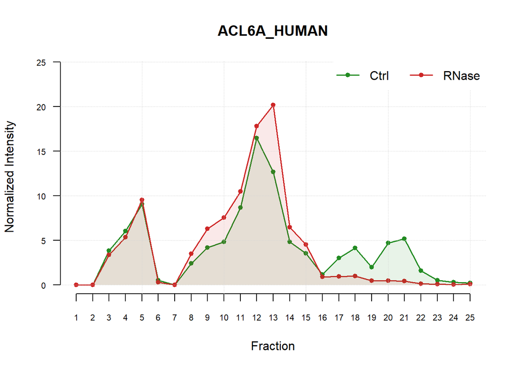

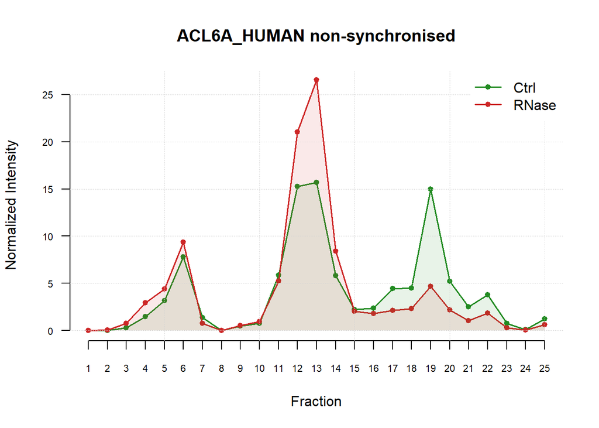

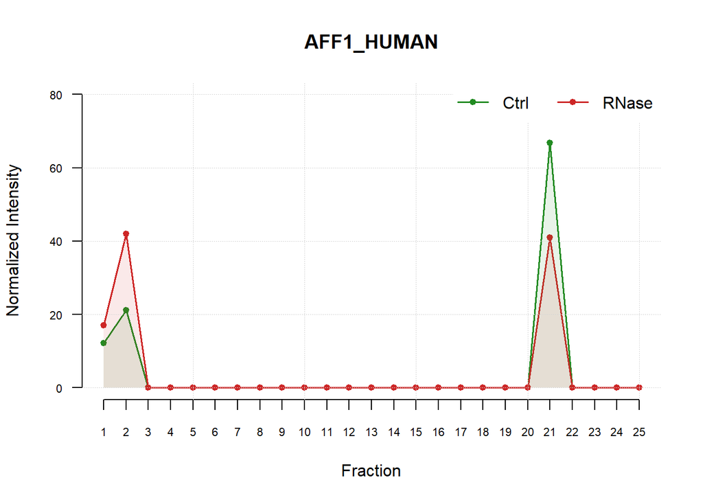

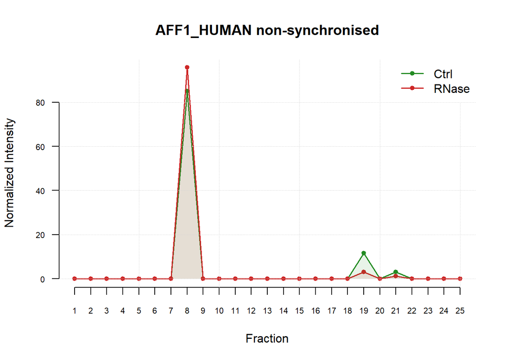

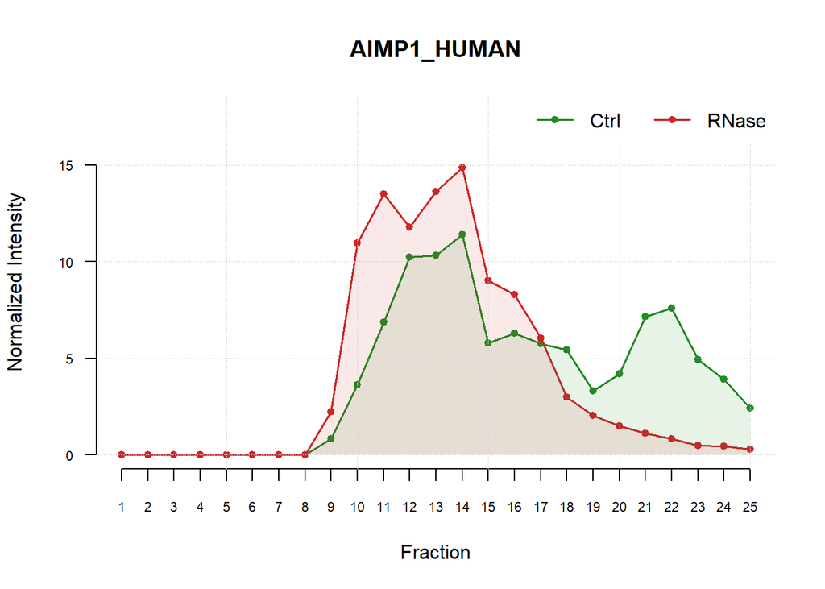

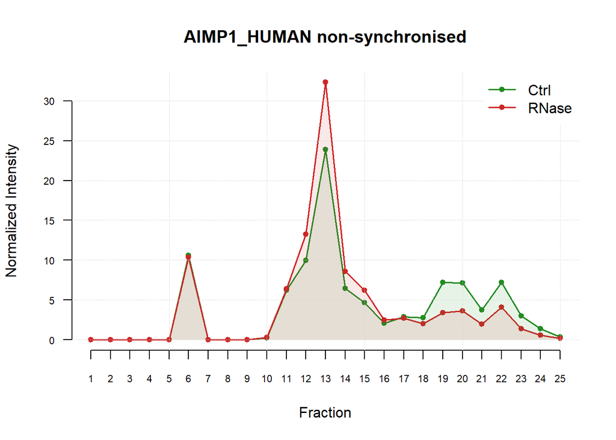

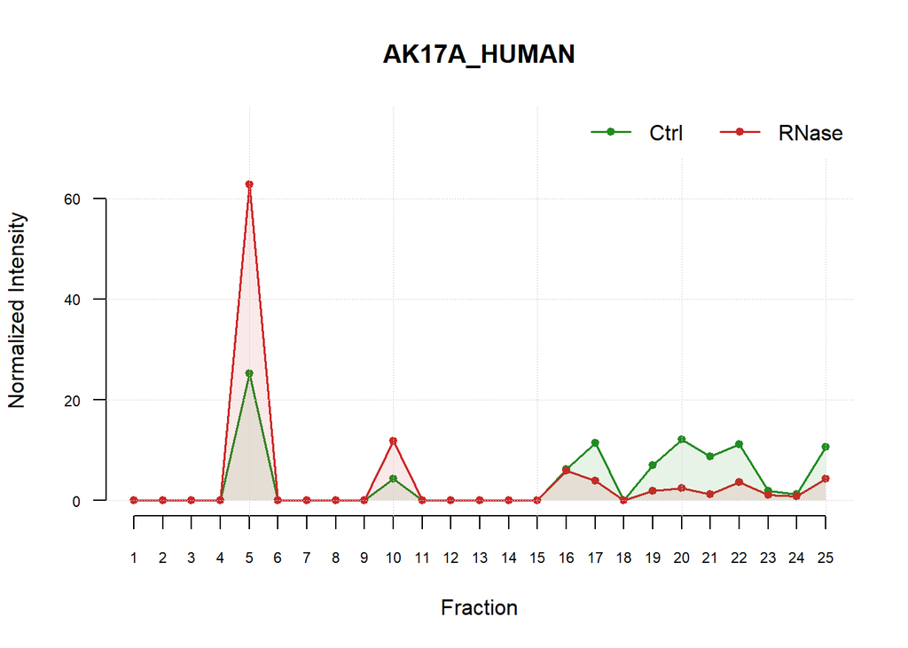

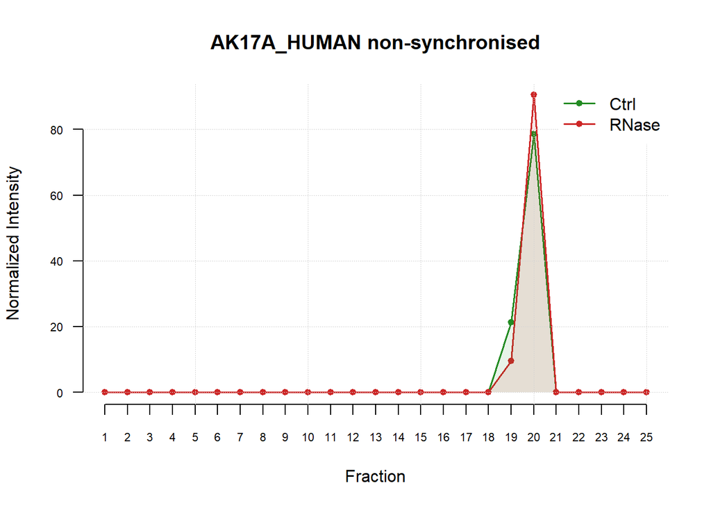

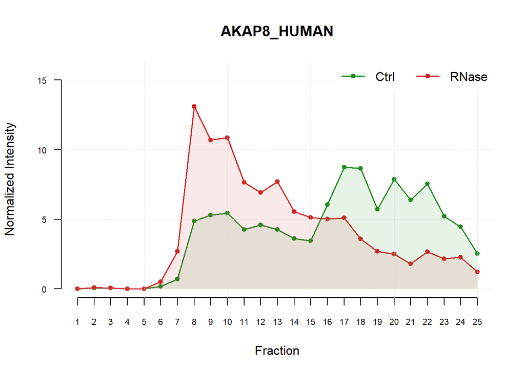

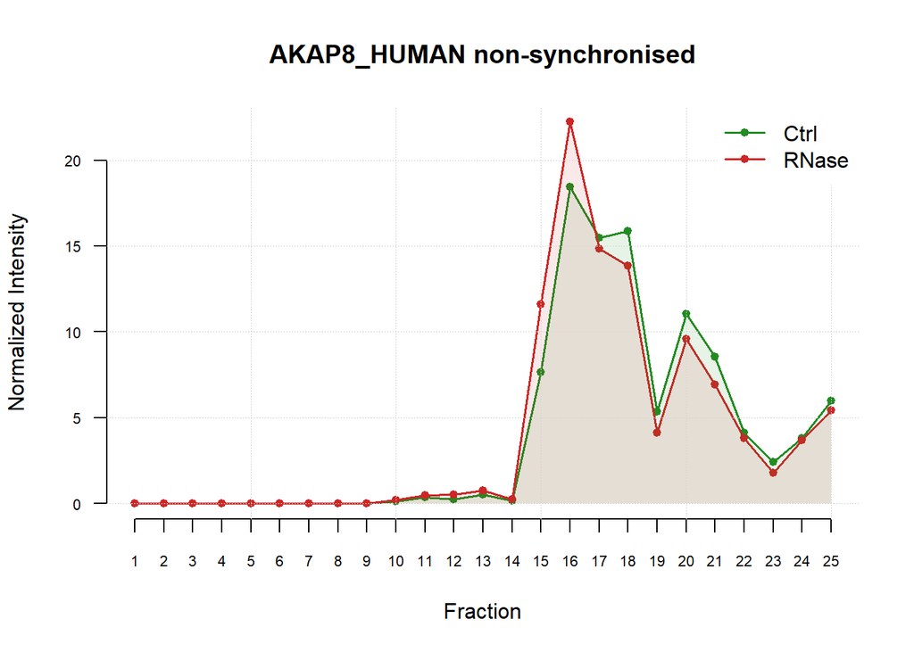

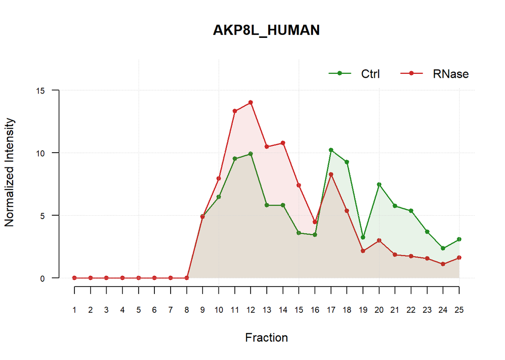

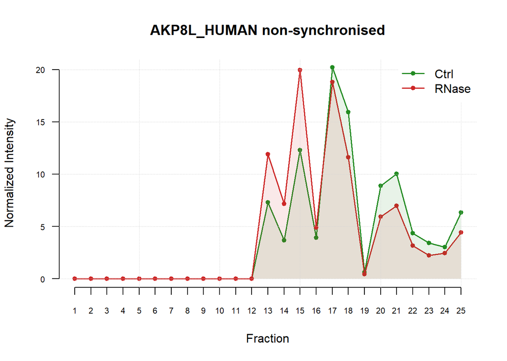

[8 more figures not shown]

```r
# Display a sample of plots (mitosis and non-synchronised) of RBPs uniquely active in mitosis
sample_RBPs_Mitosis <- head(RBPs_Mitosis,10)
for (r in sample_RBPs_Mitosis){
  plot_protein(r)
  plot_protein_NS(r)
}
```

# Visualise differences in shift characteristics

```r
# Define variables to extract from both datasets
cols_to_extract <- c("CoM_Ctrl", "CoM_RNase", "shift_distance", "shift_direction", "p_value_ttest_filtered", "significant_ttest_filtered")

# Subset and rename columns for both conditions
subset_data_S <- Shift_Data[overlap_analysis, cols_to_extract]
subset_data_NS <- Shift_Data_NS[overlap_analysis, cols_to_extract]
colnames(subset_data_S) <- paste0(colnames(subset_data_S), "_mitosis")
colnames(subset_data_NS) <- paste0(colnames(subset_data_NS), "_nonSync")

# Merge into one combined dataframe
Shift_Data_Combined <- cbind(subset_data_S,subset_data_NS)
head(Shift_Data_Combined)
```

```
##             CoM_Ctrl_mitosis CoM_RNase_mitosis shift_distance_mitosis
## AHNK_HUMAN          6.838550          6.804008             0.03454188
## PRKDC_HUMAN        14.629323         13.796488             0.83283494
## ACTB_HUMAN          5.876815          5.979347            -0.10253220
## ACTG_HUMAN          5.876815          5.979347            -0.10253220
## ACTC_HUMAN          5.836062          5.925910            -0.08984742
## ACTS_HUMAN          5.836062          5.925910            -0.08984742
##             shift_direction_mitosis p_value_ttest_filtered_mitosis
## AHNK_HUMAN                        1                      0.9975260
## PRKDC_HUMAN                       1                      0.8134208
## ACTB_HUMAN                       -1                      0.9934067
## ACTG_HUMAN                       -1                      0.9934067
## ACTC_HUMAN                       -1                      0.9935800
## ACTS_HUMAN                       -1                      0.9935800
##             significant_ttest_filtered_mitosis CoM_Ctrl_nonSync
## AHNK_HUMAN                               FALSE         10.09021
## PRKDC_HUMAN                              FALSE         14.83020
## ACTB_HUMAN                               FALSE         12.09840
## ACTG_HUMAN                               FALSE         12.09840
## ACTC_HUMAN                               FALSE         12.17772
## ACTS_HUMAN                               FALSE         12.17772
##             CoM_RNase_nonSync shift_distance_nonSync shift_direction_nonSync
## AHNK_HUMAN           9.193942             0.89627235                       1
## PRKDC_HUMAN         14.358327             0.47187324                       1
## ACTB_HUMAN          12.126841            -0.02843975                      -1
## ACTG_HUMAN          12.126841            -0.02843975                      -1
## ACTC_HUMAN          12.189021            -0.01129869                      -1
## ACTS_HUMAN          12.189021            -0.01129869                      -1
##             p_value_ttest_filtered_nonSync significant_ttest_filtered_nonSync
## AHNK_HUMAN                      0.00703533                               TRUE
## PRKDC_HUMAN                     0.03095199                               TRUE
## ACTB_HUMAN                      0.81047299                              FALSE
## ACTG_HUMAN                      0.81047299                              FALSE
## ACTC_HUMAN                      0.80948945                              FALSE
## ACTS_HUMAN                      0.80948945                              FALSE
```

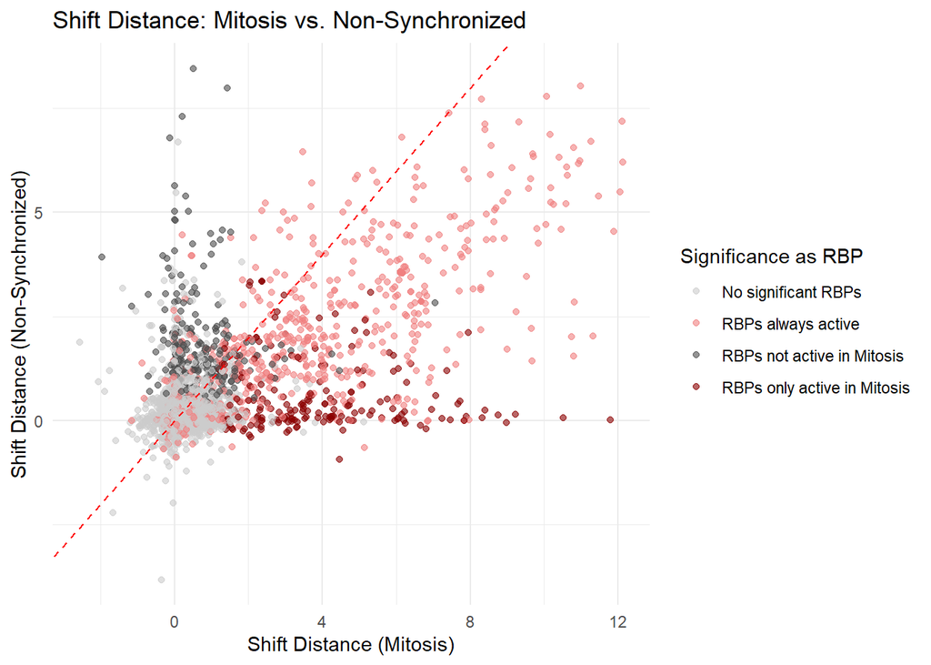

```r
# Scatterplot of shift distances

ggplot(Shift_Data_Combined, aes(x = `shift_distance_mitosis`,
                                y = `shift_distance_nonSync`,
                                color = case_when(
                                  !`significant_ttest_filtered_mitosis` & !`significant_ttest_filtered_nonSync` ~ "No significant RBPs",
                                  `significant_ttest_filtered_mitosis` & !`significant_ttest_filtered_nonSync` ~ "RBPs only active in Mitosis",
                                  !`significant_ttest_filtered_mitosis` & `significant_ttest_filtered_nonSync` ~ "RBPs not active in Mitosis",
                                  TRUE ~ "RBPs always active"
                                  ))) +
  geom_point(alpha = 0.6) +
  geom_abline(slope = 1, intercept = 0, linetype = "dashed", color = "red") +
  scale_color_manual(name = "Significance as RBP",
                     values = c(
                       "No significant RBPs" = "grey80",
                       "RBPs not active in Mitosis" = "gray30",
                       "RBPs always active" = "lightcoral",
                       "RBPs only active in Mitosis" = "darkred"
                       ))+
  labs(title = "Shift Distance: Mitosis vs. Non-Synchronized",
       x = "Shift Distance (Mitosis)",
       y = "Shift Distance (Non-Synchronized)") +
  theme_minimal()
```

# Further Data Analysis

## Additional Data for all Proteins using Uniprot and CORUM - Lina (carefull runs ~35 min!… grab a coffee :)

###Goal: Build dataframe with annotations for further analysis such as references for RNA-dependent complexes or predicting molecular weight from peak position. - Molecular weights retrieved via the UniProt REST API - Complex membership based on the CORUM database (HUMAN complexes only)

```r
# Map each protein's UniProt entry name to its accession ID
get_accession_from_entryname <- function(entry_name) {
  url <- paste0("https://rest.uniprot.org/uniprotkb/search?query=",
                entry_name, "&fields=accession&format=json&size=1")
  res <- try(GET(url), silent = TRUE)
  if (inherits(res, "try-error") || res$status_code != 200) {
    return(NA)
    }
  txt <- content(res, "text", encoding = "UTF-8")
  data <- fromJSON(txt, simplifyVector = FALSE)
  if (length(data$results) == 0) {
    return(NA)
    }
  else{
  return(data$results[[1]]$primaryAccession)
    }

}

# Function to retrieve the molecular weight from UniProt for each accession ID
get_uniprot_mass <- function(accession_ids) {
  url <- paste0("https://rest.uniprot.org/uniprotkb/", accession_ids, ".json")
  res <- try(GET(url), silent = TRUE)
  if (inherits(res, "try-error") || res$status_code != 200) {
    return(NA)
    }
  data <- fromJSON(content(res, "text", encoding = "UTF-8"))
  return(data$sequence$molWeight)
}

# Apply both functions to the MS_Table entries
entry_names <- rownames(MS_Table)
accession_ids <- pbsapply(entry_names, get_accession_from_entryname)
masses <- pbsapply(accession_ids, get_uniprot_mass)

# Convert mass results into numeric vector (set to NA for proteins with failed retrieval)
masses_vec <- rep(NA_real_, length(accession_ids))
names(masses_vec) <- accession_ids
valid_idx <- which(!sapply(masses, is.null))
masses_vec[valid_idx] <- as.numeric(unlist(masses[valid_idx]))

# Create annotated dataframe with UniProt and molecular weight
protein_data <- data.frame(
  Entry = entry_names,
  UniProtAccession = accession_ids,
  MolecularWeight_kDa = masses_vec / 1000
)

# Load CORUM data (human protein complexes only)
corum <- fread("Databanks/corum_humanComplexes.txt", sep = "\t", header = TRUE)

# Expand CORUM entries /Unlist so each UniProt ID is listed individually with its complex name
corum_expanded <- corum[, .(
  UniProtAccession = unlist(strsplit(subunits_uniprot_id, ";"))
), by = .(ComplexName = complex_name)]

corum_expanded <- unique(corum_expanded)

# Add binary Expression wheather protein is part of any complex in CORUM?
protein_data$CORUM_member <- protein_data$UniProtAccession %in% corum_expanded$UniProtAccession

# Link all complex names associated with each protein (multiple allowed)
corum_complex_list <- corum_expanded[, .(
  CORUM_complex_names = paste(unique(ComplexName), collapse = "; ")
), by = UniProtAccession]

# Add complex names to protein data
protein_data <- merge(protein_data, corum_complex_list, by = "UniProtAccession", all.x = TRUE, sort = FALSE)
protein_data$CORUM_member <- !is.na(protein_data$CORUM_complex_names)

# Background info — total number of unique proteins and complexes in CORUM
n_human_complexes <- unique(corum$complex_id)
length(n_human_complexes) # number of complexes
```

```
## [1] 5366
```

```r
all_proteins <- unlist(strsplit(corum$subunits_uniprot_id, ";"))
unique_proteins <- unique(all_proteins)
length(unique_proteins) # number of proteins in complexes
```

```
## [1] 5205
```

```r
sum(protein_data$CORUM_member== TRUE) # number of our proteins known to be in complex
```

```
## [1] 2280
```

## New Plot Protein function with all additional data

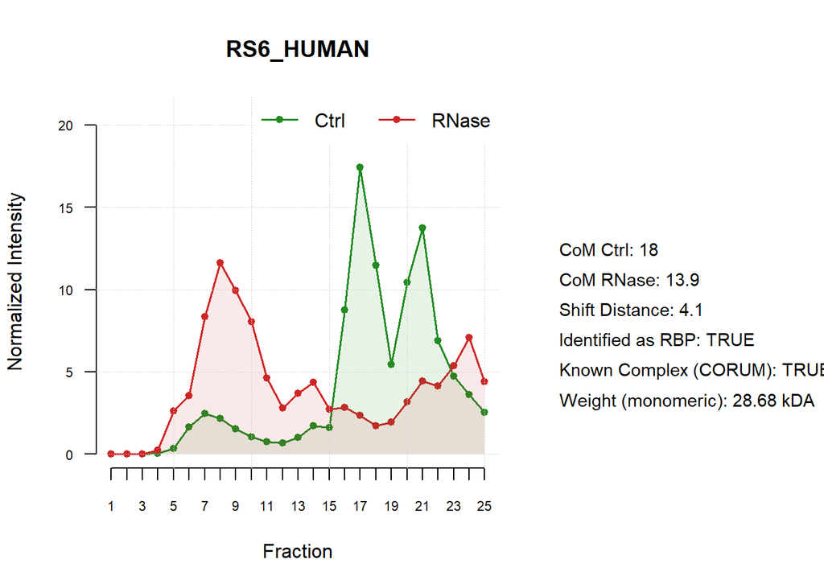

```r
plot_protein_info <- function(x) {

  # Split up plot area
  layout(matrix(1:2, nrow = 1), widths = c(4, 2))

  # Extract data, define all variables and range of x- and y-axis
  protein_of_interest <- x
  protein_row <- MS_Table_Norm[rownames(MS_Table_Norm) == protein_of_interest, ]
  ctrl_values <- as.numeric(protein_row[seq(1, 49, by=2)])
  rnase_values <- as.numeric(protein_row[seq(2, 50, by=2)])
  fractions <- 1:25
  max_val <- max(ctrl_values, rnase_values, na.rm = TRUE)
  ylim_range <- c(0, max_val * 1.2)

  # Core plot function using crtl_values
  plot(fractions, ctrl_values, type="o", pch=20, lty=1, lwd = 1.5,  col="forestgreen", ylim= ylim_range,
       xlab="Fraction", ylab="Normalized Intensity", main= protein_of_interest, axes = FALSE)

  # Add line for rnase_values
  lines(fractions, rnase_values, type="o",pch =20, lty=1, lwd = 1.5,  col="firebrick3")

  # Color area under the curve
  polygon(c(fractions, rev(fractions)),
          c(ctrl_values, rep(0, length(ctrl_values))),
          col=adjustcolor("forestgreen", alpha.f=0.1), border=NA)

  polygon(c(fractions, rev(fractions)),
          c(rnase_values, rep(0, length(rnase_values))),
          col=adjustcolor("firebrick3", alpha.f=0.1), border=NA)

  # Add x- and y-axis with correct labels
  axis(1, at = 1:25, labels = 1:25, cex.axis = 0.7)
  axis(2, cex.axis = 0.7, las =2)
  grid(nx = NULL, ny = NULL, col = "lightgray", lty = "dotted", lwd = 0.8)

  # Add legend
  legend("topright", legend=c("Ctrl", "RNase"), col=c("forestgreen", "firebrick3"),
         lty=1, lwd = 1.5,  pch=20, bg = "white", bty = "o", box.col = NA, horiz = TRUE)

  # Add info panel
  par(mar = c(0, 0, 2, 0))
  plot.new()

  shift_info <- subset_data_S[rownames(subset_data_S) == x, ]
  protein_info <- protein_data[protein_data$Entry == x, ]
  info_lines <- c(
    paste("CoM Ctrl:",round(shift_info$CoM_Ctrl_mitosis, 1)),
    paste("CoM RNase:", round(shift_info$CoM_RNase_mitosis, 1)),
    paste("Shift Distance:", round(shift_info$shift_distance_mitosis, 1)),
    paste("Identified as RBP:", shift_info$significant_ttest_filtered_mitosis),
    paste("Known Complex (CORUM):", protein_info$CORUM_member),
    paste("Weight (monomeric):", round(protein_info$MolecularWeight_kDa, 2) ,"kDA")
  )
  line_height <- 0.06
  n_lines <- length(info_lines)
  y_start <- 0.5 + (n_lines - 1) * line_height / 2
  for (i in seq_along(info_lines)) {
    y_pos <- y_start - (i - 1) * line_height
    text(x = 0, y = y_pos, labels = info_lines[i], adj = c(0, 1), cex = 0.9)
    }
}

plot_protein_info("RS6_HUMAN")
```

## Screening for RBP complexes active in Mitosis - Sofia and Cihan

### Selection of clustering criteria and hierarchical clustering

### Goal:

Select necessary parameters/dimensions and get an idea of the distribution of clusters.

### Additional Information:

Peak_data is mainly taken into consideration, specifically peak height (not position or number of peaks) we only focus on Ctrl samples, not RNase as we expect different proteins to have different distributions after RNase degradation, even when they are in the same complex. Following this logic shift data is also irrelevant. To this data we add COM of Ctrl, here peak position is relevant. Overall similar height is more important than similar peak fraction. Runs only on set of RBPS exculsively active in mitosis . Wards method (euclidean distance applied), !i think here we have to say it did not work.

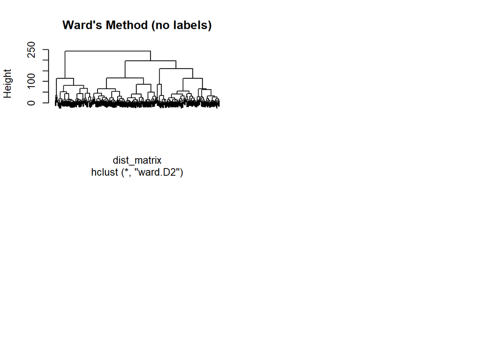

```r
#from the two shift and peak characteristics we extract some variables creating a new merged table which also has only the names of the RBPs that are aktive in mitosis !! hier stimmt was nicht.

# 1) Filter only the RBPs relevant in Mitosis

filtered_shift_Mitosis <- Shift_Data[rownames(Shift_Data) %in% RBPs_Mitosis, ]

filtered_peak_Mitosis <- Peak_Data[rownames(Peak_Data) %in% RBPs_Mitosis, ]

# 2) Selecting only the interesting coloumns creating comon dataframe

merged_filterd_mitosis <- cbind(
  filtered_shift_Mitosis[, c("CoM_Ctrl")], # selecting a specific col
  filtered_peak_Mitosis %>% select(ends_with("height_Ctrl")) # choosing only col that end with
)


# 3) clean data for further steps

# Replace NA values with 0 (when there was no peak there was not protein)
clean_merged_filterd_mitosis <- merged_filterd_mitosis
clean_merged_filterd_mitosis[is.na(clean_merged_filterd_mitosis)] <- 0


# 4) do hirarchical clustering in order to analize number of clusters that could be found


# Distance matrix (Euclidean)
dist_matrix <- dist(clean_merged_filterd_mitosis)

# Hierarchical clustering (Wards)
hc_ward <- hclust(dist_matrix, method = "ward.D2")

# Plot dendrogram
par(mfrow = c(2, 2))
#plot(hc_ward, main = "Ward's Method")


plot(hc_ward, labels = FALSE, main = "Ward's Method (no labels)")

# image for download, remove # if you want to plot:

# png("C://Users//Sofi//Desktop//4 Semester//Bioinfo_project//Downloadsdendrogram_large.png", width = 1200, height = 800)
# plot(hc_ward, labels = FALSE, main = "Ward's Method (Large Output)")
# dev.off()
```

### Goal:

Find and applying a clustering method, that will highlight proteins, which could be working in a complex.

### Additional Information:

DBSCAN is a function that can classify points in low-density regions as “noise.” This means clusters are not only defined by distance (like in k-means), but also by density. The code I wrote has two important parameters. These parameters are:

ε (epsilon): The maximum distance between two points to be considered neighbors. If this number is very small, everything is classified as noise; if it’s too large, noise may be included as relevant (resulting in one huge cluster).

MinPts: The minimum number of neighbors required for a point to be considered a so-called core point. A core point must have at least MinPts other points within ε. If this value is too low, even single points can form clusters. On the other hand, if it’s too high, only large clusters are formed and smaller ones might not be recognized at all. There are also border points, which are within ε distance of a core point but do not have enough neighbors themselves to be core points.

Everything that does not meet these conditions is filtered out and labeled as noise.

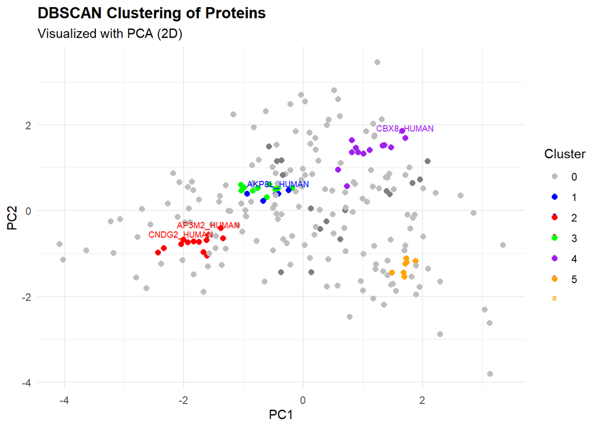

```r
# 1) Scale data

scaled_data <- scale(clean_merged_filterd_mitosis) # substracts mean, scales it by dividing sd=> data was normalized per row => here Goal is compare Proteins

# 2) DBSCAN # its important to choose eps and minPts correctly, eps is the max distance for two points to be neighbors, minPts  minimum number of points required to form a dense region.

db <- dbscan(scaled_data, eps = 0.7, minPts = 4) # parameters can be changed

# 3) PCA for plotting

pca <- prcomp(scaled_data) # function for PCA
pca_df <- as.data.frame(pca$x[, 1:2])  # PC1 and PC2, for all Proteins
pca_df$cluster <- as.factor(db$cluster)
pca_df$protein <- rownames(clean_merged_filterd_mitosis)  # Protein names from cleaned data

# 4) Plot with noise in grey

ggplot(pca_df, aes(x = PC1, y = PC2, color = cluster, label = ifelse(cluster == 0, "", protein))) +
  geom_point(size = 2) +
  geom_text(check_overlap = TRUE, size = 2.5, vjust = -1) +
  scale_color_manual(values = c("0" = "grey", "1" = "blue", "2" = "red", "3" = "green", "4" = "purple", "5" = "orange")) +
  theme_minimal() +
  labs(title = "DBSCAN Clustering of Proteins",
       subtitle = "Visualized with PCA (2D)",
       color = "Cluster") +
  theme(plot.title = element_text(face = "bold"))
```

```r
# 5) Create table: which proteins are in which cluster

clustered_proteins <- split(rownames(clean_merged_filterd_mitosis), db$cluster) # asignes the cluster to each Protein name from original dataframe

# Print each cluster's members
for (cl in sort(unique(db$cluster))) { # loops over each cluster number in sorted order

  cat(paste0("Cluster ", cl, ifelse(cl == 0, " (noise)", ""), ": ")) # pastes to console , separation of cluster name from list of Proteins

  cat(paste(clustered_proteins[[as.character(cl)]], collapse = ", ")) # extracts list of proteins and collapses them

  cat("\n\n") # adds spacing between clusters
}
```

```
## Cluster 0 (noise): ACL6A_HUMAN, AFF1_HUMAN, AK17A_HUMAN, ANO8_HUMAN, ASCC2_HUMAN, ASCC3_HUMAN, ATLA2_HUMAN, ATRX_HUMAN, BCL7A_HUMAN, BCL7B_HUMAN, BLM_HUMAN, BOP1_HUMAN, BRD3_HUMAN, BRD7_HUMAN, BRX1_HUMAN, BTF3_HUMAN, CCNK_HUMAN, CCNT1_HUMAN, CLAP1_HUMAN, CPSF3_HUMAN, CSTFT_HUMAN, DDRGK_HUMAN, DDX…
##
## Cluster 1: AIMP1_HUMAN, AKP8L_HUMAN, ATP6_HUMAN, S61A1_HUMAN, S61A2_HUMAN
##
## Cluster 2: AP3M2_HUMAN, CNDG2_HUMAN, DDX6_HUMAN, DUS2L_HUMAN, DYST_HUMAN, FGL2_HUMAN, GEMI5_HUMAN, HEXA_HUMAN, HNRPF_HUMAN, IF4G1_HUMAN, LPPRC_HUMAN, NSUN2_HUMAN, UTRO_HUMAN
##
## Cluster 3: APTX_HUMAN, NKRF_HUMAN, OAS3_HUMAN, PTCD1_HUMAN, RL30_HUMAN, RL34_HUMAN, TF3C1_HUMAN, TRM1L_HUMAN, TUT7_HUMAN, ZBT11_HUMAN
##
## Cluster 4: CBX8_HUMAN, FMR1_HUMAN, KIFC1_HUMAN, RBM6_HUMAN, RL23_HUMAN, RL27_HUMAN, RS26L_HUMAN, RS26_HUMAN, RS2_HUMAN, RS6_HUMAN, TRI25_HUMAN, UBF1_HUMAN, ZCCHV_HUMAN
##
## Cluster 5: ELYS_HUMAN, KIF14_HUMAN, NOP58_HUMAN, PRPF3_HUMAN, RBBP6_HUMAN, RFC1_HUMAN, ZC11A_HUMAN
##
## Cluster 6: H31T_HUMAN, H31_HUMAN, H32_HUMAN, H33_HUMAN
##
## Cluster 7: CKAP5_HUMAN, ESF1_HUMAN, KIN17_HUMAN, TF3C4_HUMAN, TOP2B_HUMAN
##
## Cluster 8: AKAP8_HUMAN, DDX3X_HUMAN, NCBP2_HUMAN, RS27L_HUMAN, SRSF1_HUMAN
##
## Cluster 9: RL24_HUMAN, SMCA5_HUMAN, TBL2_HUMAN, TMEM9_HUMAN
```

### Looking at plots of different clusters

###Goal: Looking if the plots look similar or not in order to validate the parameters choosen above.

Note! This code can be always run to get a better feeling over clusters

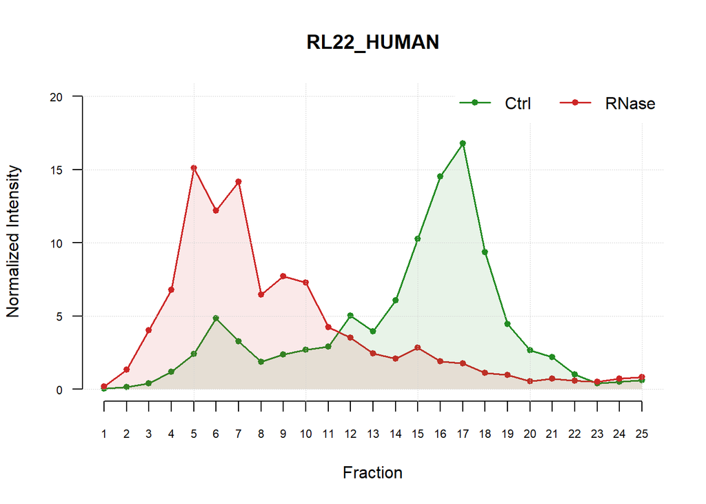

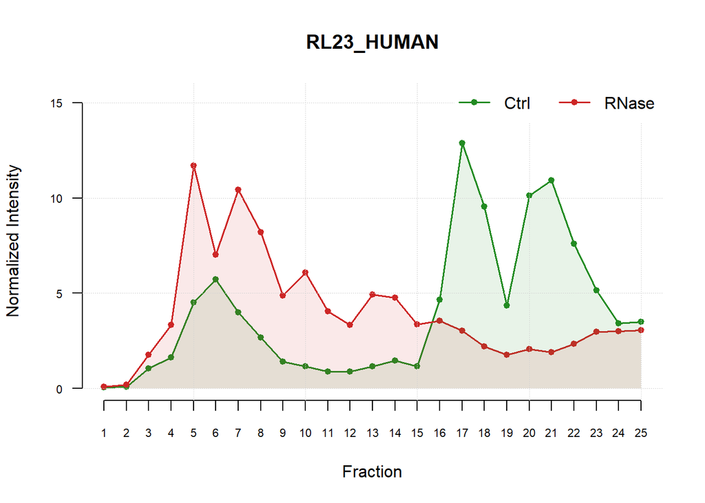

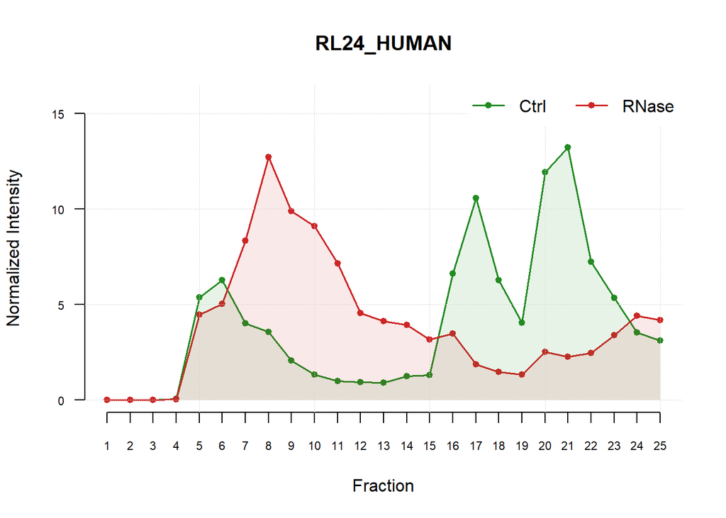

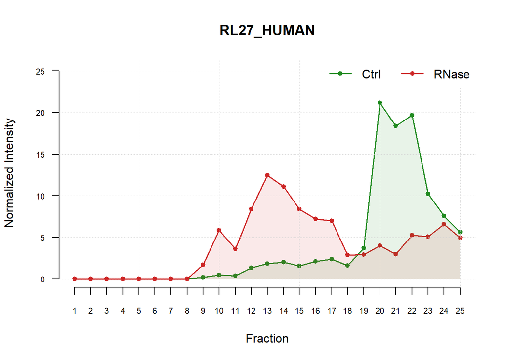

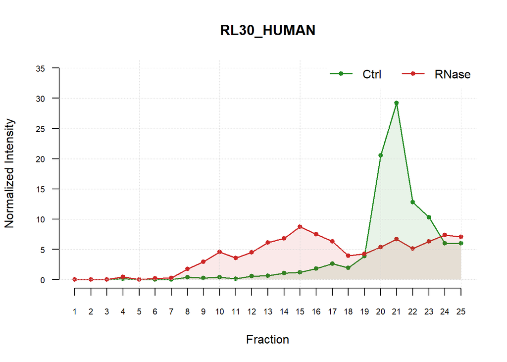

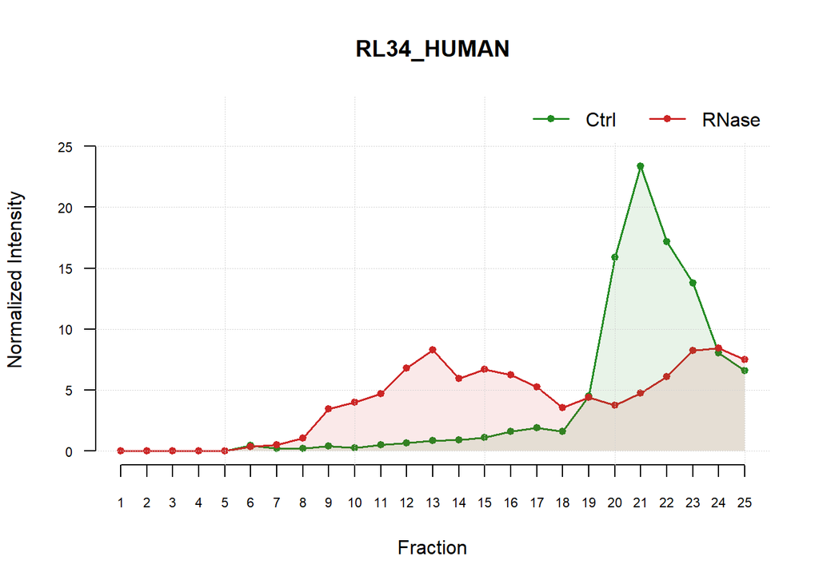

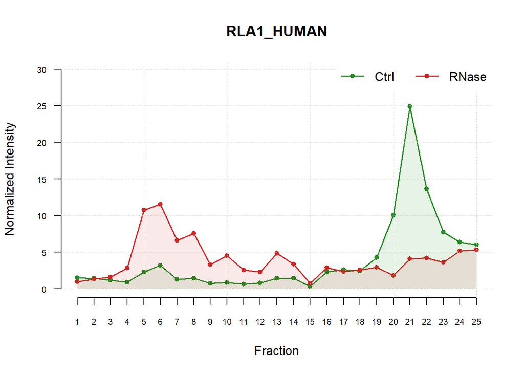

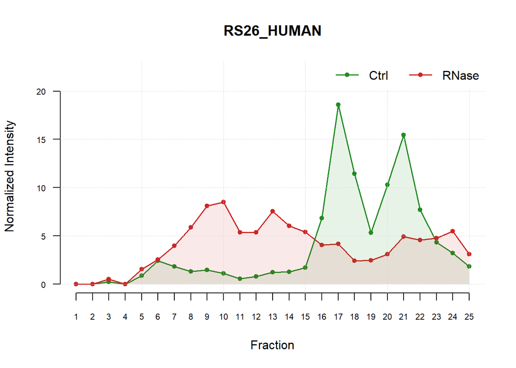

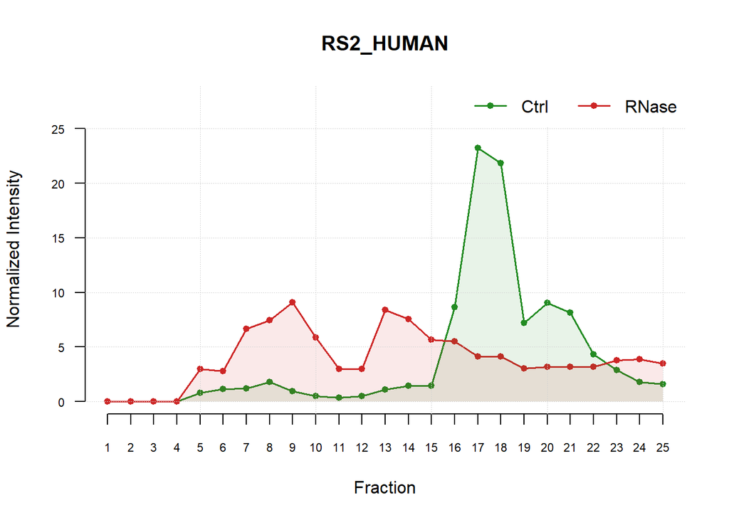

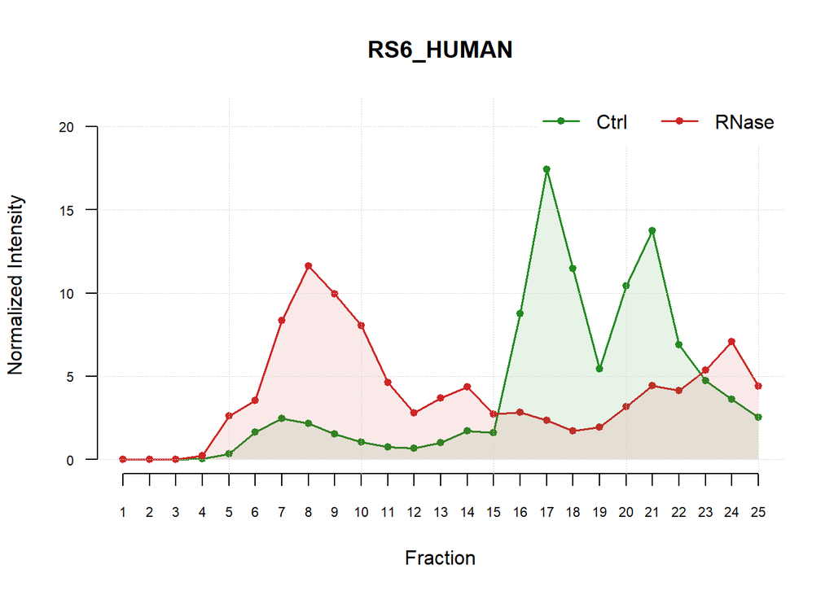

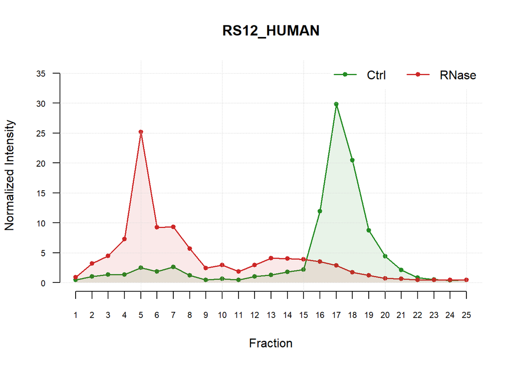

```r
# Code from ploting a protein to visualize the proteins that seam to make a complex
# View Examples

sample_RBPs_Cluster <- c("RL22_HUMAN", "RL23_HUMAN", "RL24_HUMAN", "RL27_HUMAN", "RL30_HUMAN", "RL34_HUMAN", "RLA1_HUMAN", "RS26_HUMAN", "RS2_HUMAN", "RS6_HUMAN", "RS12_HUMAN") # insert names of clustered proteins you want to compare

for (r in sample_RBPs_Cluster){
  plot_protein(r)
}
```

### Finding the right parameters to choose the perfect cluster size - Sofia

###Goal: Getting a good idea of how parameters affect our clustering results, by trying all combinations and creating a heat map based on the performance on a cluster.

Additional Information: For the heatmap we made up following logic.

1. Based on all combinations from one cluster (positive control):
- If two proteins are in the same cluster → +1
- If two proteins are in different clusters → -1
- If one or both are classified as noise → 0
2. Based on two (or more) unrelated proteins (negative control):
- If they end up in the same cluster as our example proteins → -1
- If they end up in different clusters → +1
- If noise → 0 (I’m least sure about this case)

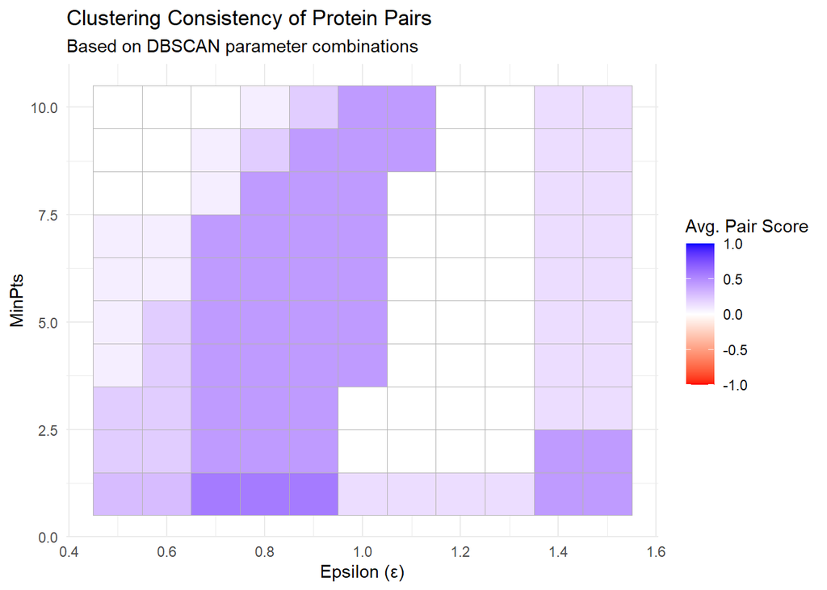

```r
# -------------- PART 1: Creating a loop for all possible combinations for ε between the numbers ( 0.5-1.5) in steps of 0.1 and for MinPts (1-10) in steps of 1 ----------

# 1. Scale data like chunk before
scaled_data <- scale(clean_merged_filterd_mitosis)
protein_names <- rownames(clean_merged_filterd_mitosis)
n_proteins <- nrow(scaled_data)

# 2. Create empty data frame to collect results
results_df <- data.frame(row.names = protein_names)

# 3. Loop over all combinations
for (eps in seq(0.5, 1.5, by = 0.1)) {
  for (minPts in 1:10) {

    # Run DBSCAN
    db <- dbscan(scaled_data, eps = eps, minPts = minPts) # runs combinations

    # Store cluster assignments
    col_name <- paste0("eps_", eps, "_minPts_", minPts)
    results_df[[col_name]] <- db$cluster
  }
}

# -------------- PART 2: Creating a loop for all possible combinations for ε between the numbers ( 0.5-1.5) in steps of 0.1 and for MinPts (1-10) in steps of 1 ----------


# 1)Define your proteins of interest ( from Corum Data)

target_proteins <- c("RS12_HUMAN", "RS26_HUMAN", "RS2_HUMAN", "RS6_HUMAN") # this would be positiv controll, a complex we know about.

negative_controls <- c("LPPRC_HUMAN", "UIMC1_HUMAN")

all_proteins <- c(target_proteins, negative_controls)

# 2) create all pairwise combinations (postiv control)

protein_pairs <- combn(all_proteins, 2, simplify = FALSE)

# --- Step 4: scoring for each DBSCAN setting ---

score_results <- data.frame()

for (col_name in colnames(results_df)) { # selcts all coloums from DBSCAN combinations

  cluster_assignments <- as.numeric(results_df[[col_name]]) # extracts data and converts to numeric

  names(cluster_assignments) <- rownames(results_df) # assignes its cluster number back to its protein name

  pair_scores <- c()

  for (pair in protein_pairs) {
    p1 <- pair[1] # selects first protein
    p2 <- pair[2] # selects second protein
    c1 <- cluster_assignments[p1]
    c2 <- cluster_assignments[p2]

    # Skip if NA
    if (is.na(c1) || is.na(c2)) {
      score <- NA

    # Both are targets
    } else if (p1 %in% target_proteins && p2 %in% target_proteins) {
      if (c1 == 0 || c2 == 0) {
        score <- 0 # noise is always 0
      } else if (c1 == c2) {
        score <- 1 # here when the two clusters are equal, its good
      } else {
        score <- -1
      }

    # One is negative control, one is target
    } else if ((p1 %in% negative_controls && p2 %in% target_proteins) ||
               (p2 %in% negative_controls && p1 %in% target_proteins)) {
      if (c1 == 0 || c2 == 0) {
        score <- 0 # noise is always 0
      } else if (c1 == c2) {
        score <- -1 # here when the two clusters are equal its bad
      } else {
        score <- 1  # Properly separated
      }

    # Both are negative controls – don't score this pair
    } else {
      next # skips scoring booth negatives
    }

    pair_scores <- c(pair_scores, score) # apart from neg neg pairs all resulting scores are listed
  }

  avg_score <- mean(pair_scores, na.rm = TRUE) # computes the avaredge

  parts <- strcapture("eps_([0-9.]+)_minPts_([0-9]+)", col_name, data.frame(eps = 0, minPts = 0))# extracts from colnames the values for eps and minPts as numbers

  score_results <- rbind(score_results, data.frame( # three columns
    eps = as.numeric(parts$eps),
    minPts = as.numeric(parts$minPts),
    score = avg_score
  ))
}

# --- Step 6: Plot heatmap ---
ggplot(score_results, aes(x = eps, y = minPts, fill = score)) +
  geom_tile(color = "grey70") +
  scale_fill_gradient2(low = "red", mid = "white", high = "blue", midpoint = 0, limits = c(-1, 1)) +
  labs(title = "Clustering Consistency of Protein Pairs",
       subtitle = "Based on DBSCAN parameter combinations",
       x = "Epsilon (ε)",
       y = "MinPts",
       fill = "Avg. Pair Score") +
  theme_minimal()
```

## Testing R-Deep for further use in molecular weight predictions (Linear Regression) - Lina

### GoaL:

Investigate whether a linear model predicting molecular weight based on RNase values of this method (maximal peak position) can predict the molecular weight of proteins after RNase treatment.

–> Conclusion: This approach does NOT yield a valid predictive model! Possible reasons include:

- Elution position depends not only on mass, but also shape and density of the protein.
- Many proteins remain in RNA-independent protein complexes even after RNase treatment.(However, even after removing CORUM complex proteins, no strong correlation appears)
- Maximal Peak Position is not the correct parameter to predict molecular weight. (However, also parameter CoM showed no correlation)
- Peak-based features (e.g. max position or CoM) are too simplistic for modeling this complex system

```r
# Extract the position of the strongest (highest) peak for each protein in the RNase condition
max_peak_positions <- numeric(nrow(Peak_Data))

for (p in seq_len(nrow(Peak_Data))) {
  p_data <- Peak_Data [p,]
  peak_heights <- as.numeric(p_data[, paste0("peak", 1:6, "_height_RNase")])
  peak_positions <- as.numeric(p_data[, paste0("peak", 1:6, "_position_RNase")])

  if (all(is.na(peak_heights))) {
    max_peak_positions[p] <- NA
  } else {
    max_idx <- which.max(peak_heights)
    max_peak_positions[p] <- peak_positions[max_idx]
  }

}
# Combine with molecular weight and center of mass information
Protein_Data_for_LR <- data.frame(
  max_peak_position_RNase = max_peak_positions,
  MolecularWeight_kDa = protein_data$MolecularWeight_kDa,
  CoM_RNase = Shift_Data$CoM_RNase
)
rownames(Protein_Data_for_LR) <- rownames(Peak_Data)

# Spearman correlation: molecular weight vs. strongest peak position
cor.test(Protein_Data_for_LR$max_peak_position_RNase,
         Protein_Data_for_LR$MolecularWeight_kDa,
         method = "spearman", use = "complete.obs")
```

```
##
##  Spearman's rank correlation rho
##
## data:  Protein_Data_for_LR$max_peak_position_RNase and Protein_Data_for_LR$MolecularWeight_kDa
## S = 6.1587e+10, p-value = 0.374
## alternative hypothesis: true rho is not equal to 0
## sample estimates:
##         rho
## -0.01051527
```

```r
# Linear model: can we predict molecular weight from peak position?
lm_model_peak_position <- lm(MolecularWeight_kDa ~ max_peak_position_RNase, data = Protein_Data_for_LR)
summary(lm_model_peak_position)
```

```
##
## Call:
## lm(formula = MolecularWeight_kDa ~ max_peak_position_RNase, data = Protein_Data_for_LR)
##
## Residuals:
##    Min     1Q Median     3Q    Max
##  -65.9  -42.2  -19.5   15.8 3749.8
##
## Coefficients:
##                         Estimate Std. Error t value Pr(>|t|)
## (Intercept)              67.5733     1.9395  34.840   <2e-16 ***
## max_peak_position_RNase  -0.1449     0.1782  -0.813    0.416
## ---
## Signif. codes:  0 '***' 0.001 '**' 0.01 '*' 0.05 '.' 0.1 ' ' 1
##
## Residual standard error: 84.14 on 7149 degrees of freedom
##   (8 Beobachtungen als fehlend gelöscht)
## Multiple R-squared:  9.245e-05,  Adjusted R-squared:  -4.742e-05
## F-statistic: 0.661 on 1 and 7149 DF,  p-value: 0.4162
```

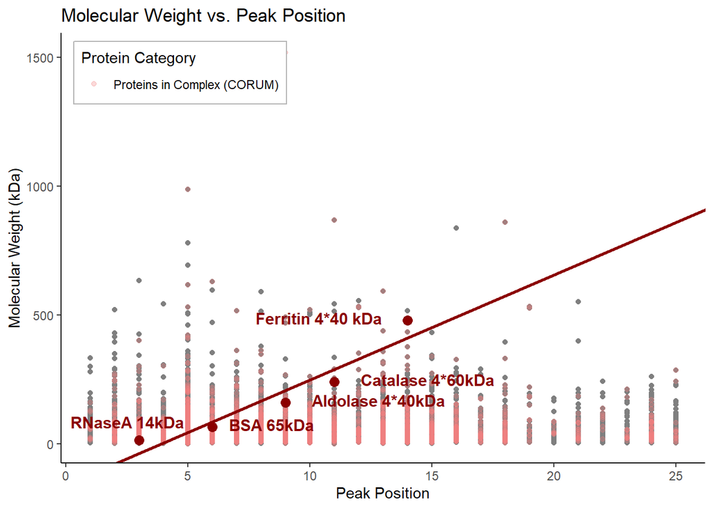

```r
# 5 reference proteins with known molecular weight and elution fraction (Caudron et al.)
reference_proteins <- data.frame(
   x = c(3, 6, 9, 11, 14),
   y = c(14, 65, 160, 240, 480),
   name = c("RNaseA 14kDa", "BSA 65kDa", "Aldolase 4*40kDa", "Catalase 4*60kDa", "Ferritin 4*40 kDa")
)

# Linear fit through reference points
linear_reference <- lm(y ~ x, data = reference_proteins)

# Extract subset of CORUM-listed complex members (for highlighting in scatter plot)
CORUM_comlexes <- protein_data[protein_data$CORUM_member == TRUE, ]
CORUM_comlexes <- Protein_Data_for_LR[rownames(Protein_Data_for_LR) %in% CORUM_comlexes$Entry, ]

# Scatter plot with reference line and annotations
ggplot(Protein_Data_for_LR %>% filter(MolecularWeight_kDa <= 1000), aes(x = max_peak_position_RNase, y = MolecularWeight_kDa)) +
  geom_point(aes(color = "All analyzed Proteins")) +
  geom_point(data = CORUM_comlexes,aes(x = max_peak_position_RNase, y = MolecularWeight_kDa, color = "Proteins in Complex (CORUM)"),alpha = 0.3)  +
  geom_abline(intercept = coef(linear_reference)[1],
              slope = coef(linear_reference)[2],
              color = "darkred", size = 1) +
  geom_point(data = reference_proteins, aes(x = x, y = y), color = "darkred", size = 3) +
  geom_text(data = reference_proteins[c(1), ], aes(x = x, y = y, label = name),
            vjust = -1,   hjust = 0.6, color = "darkred", size = 4, fontface = "bold") +
  geom_text(data = reference_proteins[c(5), ], aes(x = x, y = y, label = name),
            vjust = 0.3 ,   hjust = 1.2, color = "darkred", size = 4, fontface = "bold") +
  geom_text(data = reference_proteins[c(2, 3, 4), ], aes(x = x, y = y, label = name),
            vjust = 0.3,   hjust = -0.2, color = "darkred", size = 4, fontface = "bold") +
  theme_classic() +
  theme(
    legend.position = c(0.02, 0.98),
    legend.justification = c("left", "top"),
    legend.background = element_rect(fill = "white",color = "gray70")) +
  scale_color_manual(values = c("All analysed Proteins" = "gray75", "Proteins in Complex (CORUM)" = "lightcoral"))+
  labs(x = "Peak Position", y = "Molecular Weight (kDa)", color = "Protein Category",
    title = "Molecular Weight vs. Peak Position ")
```